# Comprehensive Analysis of Forest Cover Types: Data Preparation, Exploration, Modelling, and Evaluation

## Task 1 - Problem Formulation, Data Acquisition and Preparation

```python
import numpy as np
import pandas as pd
import matplotlib.pyplot as plt

# Define column names for the DataFrame based on the attribute information provided
column_names = [
    "Elevation", "Aspect", "Slope", "Horizontal_Distance_To_Hydrology",
    "Vertical_Distance_To_Hydrology", "Horizontal_Distance_To_Roadways",
    "Hillshade_9am", "Hillshade_Noon", "Hillshade_3pm",
    "Horizontal_Distance_To_Fire_Points",
    "Rawah_Wilderness_Area", "Neota_Wilderness_Area", "Comanche_Peak_Wilderness_Area",
    "Cache_la_Poudre_Wilderness_Area",
    "CathedralFamily", "Vanet_RatakeFamilies", "Haploborolis",
    "RatakeFamily", "VanetFamily", "Vanet_WetmoreFamilies",
    "GothicFamily", "Supervisor_LimberFamilies", "TroutvilleFamily", "Bullwark_CatamountFamilies_Rockoutcrop",
    "Bullwark_Catamount_RockLand", "LegaultFamily", "CatamountFamily",
    "PachicArgiborolis", "Unknown", "Cryaquolis",
    "Gateview", "RogertFamily", "TypicCryaquolis_BorohemistsComplex",
    "TypicCryaquepts_TypicCryaquollsComplex", "TypicCryaquolls_Leighcancomplex",
    "LeighcanFamily_TillSubstratum_ExtremelyBouldery", "LeighcanFamily_TillSubstratum_TypicCryaquollsComplex",
    "Leighcan", "Leighcan_warm", "Granile_Catamount_complex",
    "Leighcan_warm_Rock_outcrop_complex", "Leighcan_Rock_outcrop_complex",
    "Como_Legault_complex", "Como_Rock_land_Legault_complex",
    "Leighcan_Catamount_complex", "Catamount_Rock_outcrop_Leighcan_complex",
    "Leighcan_Catamount_Rock_outcrop_complex", "Cryorthents_Rock_land_complex",
    "Cryumbrepts_Rock_outcrop_Cryaquepts_complex", "Bross_Rock_land_Cryumbrepts_complex",
    "Rock_outcrop_Cryumbrepts_Cryorthents_complex",
    "Leighcan_Moran_Cryaquolls_complex", "Moran_Cryorthents_Leighcan_complex",
    "Moran_Cryorthents_Rock_land_complex",
    "Cover_Type"
]

df_main = pd.read_csv("covtype.data", names=column_names)

df_main.head()
```

|  | Elevation | Aspect | Slope | Horizontal_Distance_To_Hydrology | Vertical_Distance_To_Hydrology | Horizontal_Distance_To_Roadways | Hillshade_9am | Hillshade_Noon | Hillshade_3pm | Horizontal_Distance_To_Fire_Points | ... | Catamount_Rock_outcrop_Leighcan_complex | Leighcan_Catamount_Rock_outcrop_complex | Cryorthents_Rock_land_complex | Cryumbrepts_Rock_outcrop_Cryaquepts_complex | Bross_Rock_land_Cryumbrepts_complex | Rock_outcrop_Cryumbrepts_Cryorthents_complex | Leighcan_Moran_Cryaquolls_complex | Moran_Cryorthents_Leighcan_complex | Moran_Cryorthents_Rock_land_complex | Cover_Type |
| --- | --- | --- | --- | --- | --- | --- | --- | --- | --- | --- | --- | --- | --- | --- | --- | --- | --- | --- | --- | --- | --- |
| 0 | 2596 | 51 | 3 | 258 | 0 | 510 | 221 | 232 | 148 | 6279 | ... | 0 | 0 | 0 | 0 | 0 | 0 | 0 | 0 | 0 | 5 |
| 1 | 2590 | 56 | 2 | 212 | -6 | 390 | 220 | 235 | 151 | 6225 | ... | 0 | 0 | 0 | 0 | 0 | 0 | 0 | 0 | 0 | 5 |
| 2 | 2804 | 139 | 9 | 268 | 65 | 3180 | 234 | 238 | 135 | 6121 | ... | 0 | 0 | 0 | 0 | 0 | 0 | 0 | 0 | 0 | 2 |
| 3 | 2785 | 155 | 18 | 242 | 118 | 3090 | 238 | 238 | 122 | 6211 | ... | 0 | 0 | 0 | 0 | 0 | 0 | 0 | 0 | 0 | 2 |
| 4 | 2595 | 45 | 2 | 153 | -1 | 391 | 220 | 234 | 150 | 6172 | ... | 0 | 0 | 0 | 0 | 0 | 0 | 0 | 0 | 0 | 5 |

5 rows × 55 columns

```python
#Check data type and number of non-null values in each column

df_main.info()
```

```
<class 'pandas.core.frame.DataFrame'>
RangeIndex: 581012 entries, 0 to 581011
Data columns (total 55 columns):
 #   Column                                                Non-Null Count   Dtype
---  ------                                                --------------   -----
 0   Elevation                                             581012 non-null  int64
 1   Aspect                                                581012 non-null  int64
 2   Slope                                                 581012 non-null  int64
 3   Horizontal_Distance_To_Hydrology                      581012 non-null  int64
 4   Vertical_Distance_To_Hydrology                        581012 non-null  int64
 5   Horizontal_Distance_To_Roadways                       581012 non-null  int64
 6   Hillshade_9am                                         581012 non-null  int64
 7   Hillshade_Noon                                        581012 non-null  int64
 8   Hillshade_3pm                                         581012 non-null  int64
 9   Horizontal_Distance_To_Fire_Points                    581012 non-null  int64
```

[output cut: 47 more lines]

### Handling Missing values

```python
#Print the number of columns and rows in a DataFrame that have missing values

print("No. of Columns having missing values: ", df_main.isnull().any().sum())
print("No. of Rows having missing values: ", df_main.isnull().any(axis=1).sum())
```

```
No. of Columns having missing values:  0
No. of Rows having missing values:  0
```

**There are no missing values in the dataframe**

### Checking for Duplicates

#### Finding duplicate rows

```python
#Find the number of duplicate rows in the dataframe

df_main.duplicated().sum()
```

```
0
```

**There are no duplicate rows in the dataframe**

### Checking for class imbalance

```python
# Map the cover type values to their corresponding labels
cover_type_labels = {
    1: 'Spruce/Fir',
    2: 'Lodgepole Pine',
    3: 'Ponderosa Pine',
    4: 'Cottonwood/Willow',
    5: 'Aspen',
    6: 'Douglas-fir',
    7: 'Krummholz'
}

subset_data = df_main['Cover_Type']

subset_data = subset_data.map(cover_type_labels)

subset_data.value_counts()
```

```
Lodgepole Pine       283301
Spruce/Fir           211840
Ponderosa Pine        35754
Krummholz             20510
Douglas-fir           17367
Aspen                  9493
Cottonwood/Willow      2747
Name: Cover_Type, dtype: int64
```

### Create categorical columns, and remove corresponding binary columns

```python
df = df_main.copy()

# Extract the binary columns related to soil types
soil_columns = column_names[column_names.index("CathedralFamily"):column_names.index("Moran_Cryorthents_Rock_land_complex")+1]

# Extract the binary columns related to wilderness areas
wilderness_area_columns = column_names[column_names.index("Rawah_Wilderness_Area"):column_names.index("Cache_la_Poudre_Wilderness_Area")+1]

# Create the 'soil_type' column
df['soil_type'] = df[soil_columns].idxmax(axis=1).apply(lambda x: x.split("_")[0])

# Create the 'wilderness_area' column
df['wilderness_area'] = df[wilderness_area_columns].idxmax(axis=1).apply(lambda x: x.split("_")[0])

# Drop the binary columns
df.drop(soil_columns, axis=1, inplace=True)
df.drop(wilderness_area_columns, axis=1, inplace=True)
df
```

|  | Elevation | Aspect | Slope | Horizontal_Distance_To_Hydrology | Vertical_Distance_To_Hydrology | Horizontal_Distance_To_Roadways | Hillshade_9am | Hillshade_Noon | Hillshade_3pm | Horizontal_Distance_To_Fire_Points | Cover_Type | soil_type | wilderness_area |
| --- | --- | --- | --- | --- | --- | --- | --- | --- | --- | --- | --- | --- | --- |
| 0 | 2596 | 51 | 3 | 258 | 0 | 510 | 221 | 232 | 148 | 6279 | 5 | Como | Rawah |
| 1 | 2590 | 56 | 2 | 212 | -6 | 390 | 220 | 235 | 151 | 6225 | 5 | Como | Rawah |
| 2 | 2804 | 139 | 9 | 268 | 65 | 3180 | 234 | 238 | 135 | 6121 | 2 | LegaultFamily | Rawah |
| 3 | 2785 | 155 | 18 | 242 | 118 | 3090 | 238 | 238 | 122 | 6211 | 2 | Como | Rawah |
| 4 | 2595 | 45 | 2 | 153 | -1 | 391 | 220 | 234 | 150 | 6172 | 5 | Como | Rawah |
| ... | ... | ... | ... | ... | ... | ... | ... | ... | ... | ... | ... | ... | ... |
| 581007 | 2396 | 153 | 20 | 85 | 17 | 108 | 240 | 237 | 118 | 837 | 3 | Vanet | Comanche |
| 581008 | 2391 | 152 | 19 | 67 | 12 | 95 | 240 | 237 | 119 | 845 | 3 | Vanet | Comanche |
| 581009 | 2386 | 159 | 17 | 60 | 7 | 90 | 236 | 241 | 130 | 854 | 3 | Vanet | Comanche |
| 581010 | 2384 | 170 | 15 | 60 | 5 | 90 | 230 | 245 | 143 | 864 | 3 | Vanet | Comanche |
| 581011 | 2383 | 165 | 13 | 60 | 4 | 67 | 231 | 244 | 141 | 875 | 3 | Vanet | Comanche |

581012 rows × 13 columns

## Task 2 - Data Exploration

### Function for exploration of numerical columns by providing descriptive statistics and graphical visualisations.

```python
def explore_numerical_column(df, column_name):
    # Descriptive Statistics
    print('Descriptive Statistics:')
    statistics = df[column_name].describe().to_dict()
    statistics_line1 = ", ".join([f"{stat.capitalize()}: {value:.2f}" for stat, value in statistics.items() if stat != 'count'])
    print(statistics_line1)

    # Graphical Visualisations
    fig, (ax1, ax2) = plt.subplots(1, 2, figsize=(16, 6))

    # Histogram
    hist, bin_edges, _ = ax1.hist(df[column_name], bins=20, edgecolor = 'black', alpha=0.7)
    ax1.set_xlabel(column_name)
    ax1.set_ylabel("Frequency")
    ax1.set_title("Distribution of " + column_name)
    ax1.set_xticks(bin_edges)
    ax1.set_xticklabels([f"{label:.1f}" for label in bin_edges], rotation=90)

    # Boxplot
    ax2.boxplot(df[column_name])
    ax2.set_xlabel(column_name)
    ax2.set_ylabel("Value")
    ax2.set_title("Boxplot of " + column_name)

    plt.tight_layout()
    plt.savefig(column_name + "_exploration.png", dpi=300, bbox_inches="tight")  # Save combined image
    plt.show()
```

### Function for exploration of categorical columns by providing descriptive statistics and graphical visualisations.

```python
def explore_categorical_column(df, column_name):
    print('Descriptive Statistics:')
    # Summary
    summary = df[column_name].describe()

    # Unique Categories
    unique_categories = df[column_name].unique()

    # Number of Unique Categories
    num_unique_categories = len(unique_categories)

    # Display Summary and Number of Unique Categories
    print(summary)
    print("Number of Unique Categories:", num_unique_categories)

    # Graphical Visualisation - Bar Plot
    plt.figure(figsize=(10, 8))
    counts = df[column_name].value_counts()
    counts.plot(kind='bar')
    plt.xlabel(column_name)
    plt.ylabel("Frequency")
    plt.title("Distribution of " + column_name)
    plt.xticks(rotation=90)
    plt.tight_layout()
    plt.savefig(column_name + "_exploration.png",  dpi=300, bbox_inches="tight")  # Save bar plot image
    plt.show()
```

### 2.1 Exploring Columns

### Column 1 - "Elevation"

```
Descriptive Statistics:
Mean: 2959.37, Std: 279.98, Min: 1859.00, 25%: 2809.00, 50%: 2996.00, 75%: 3163.00, Max: 3858.00
```

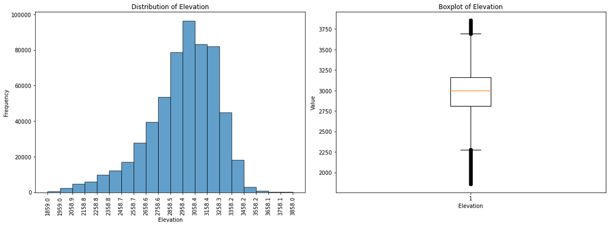

```python
explore_numerical_column(df, "Elevation")
```

### Column 2 - "Aspect"

```
Descriptive Statistics:
Mean: 155.66, Std: 111.91, Min: 0.00, 25%: 58.00, 50%: 127.00, 75%: 260.00, Max: 360.00
```

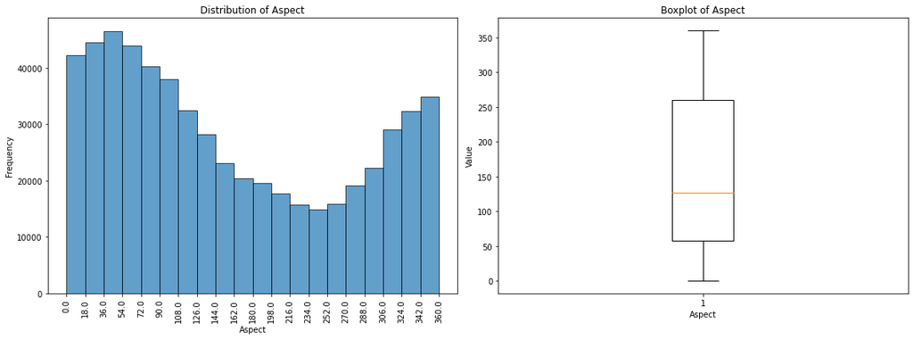

```python
explore_numerical_column(df, "Aspect")
```

### Column 3 - "Slope"

```
Descriptive Statistics:
Mean: 14.10, Std: 7.49, Min: 0.00, 25%: 9.00, 50%: 13.00, 75%: 18.00, Max: 66.00
```

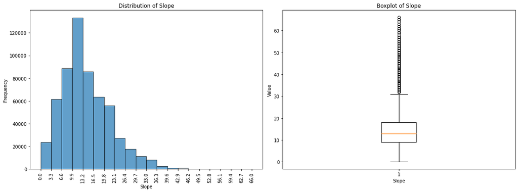

```python
explore_numerical_column(df, "Slope")
```

### Column 4 - "Horizontal_Distance_To_Hydrology"

```
Descriptive Statistics:
Mean: 269.43, Std: 212.55, Min: 0.00, 25%: 108.00, 50%: 218.00, 75%: 384.00, Max: 1397.00
```

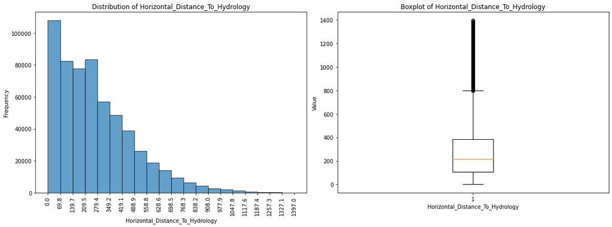

```python
explore_numerical_column(df,"Horizontal_Distance_To_Hydrology")
```

### Column 5 - "Vertical_Distance_To_Hydrology"

```
Descriptive Statistics:
Mean: 46.42, Std: 58.30, Min: -173.00, 25%: 7.00, 50%: 30.00, 75%: 69.00, Max: 601.00
```

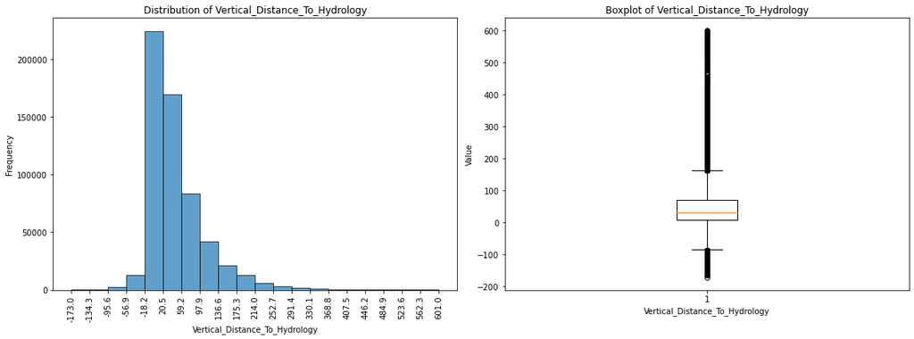

```python
explore_numerical_column(df, "Vertical_Distance_To_Hydrology")
```

### Column 6 - "Horizontal_Distance_To_Roadways"

```
Descriptive Statistics:
Mean: 2350.15, Std: 1559.25, Min: 0.00, 25%: 1106.00, 50%: 1997.00, 75%: 3328.00, Max: 7117.00
```

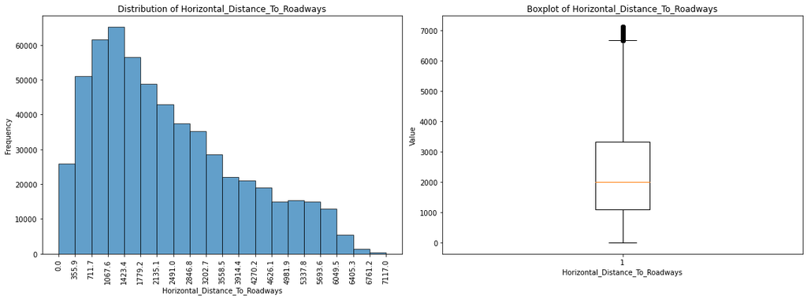

```python
explore_numerical_column(df, "Horizontal_Distance_To_Roadways")
```

### Column 7 - "Horizontal_Distance_To_Fire_Points"

```
Descriptive Statistics:
Mean: 1980.29, Std: 1324.20, Min: 0.00, 25%: 1024.00, 50%: 1710.00, 75%: 2550.00, Max: 7173.00
```

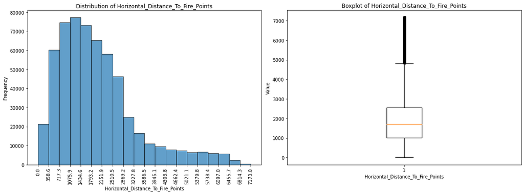

```python
explore_numerical_column(df, "Horizontal_Distance_To_Fire_Points")
```

### Column 8 - "Hillshade_9am"

```
Descriptive Statistics:
Mean: 212.15, Std: 26.77, Min: 0.00, 25%: 198.00, 50%: 218.00, 75%: 231.00, Max: 254.00
```

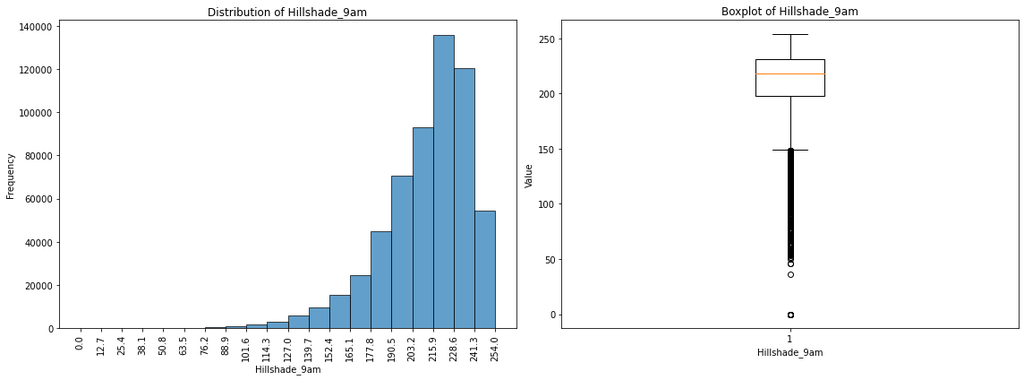

```python
explore_numerical_column(df, "Hillshade_9am")
```

### Column 9 - "soil_type"

```
Descriptive Statistics:
count     581012
unique        29
top         Como
freq      145417
Name: soil_type, dtype: object
Number of Unique Categories: 29
```

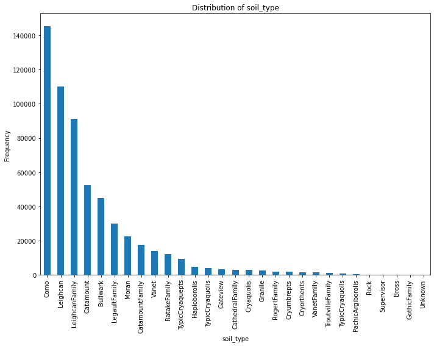

```python
explore_categorical_column(df, "soil_type")
```

### Column 10 - "wilderness_area"

```
Descriptive Statistics:
count     581012
unique         4
top        Rawah
freq      260796
Name: wilderness_area, dtype: object
Number of Unique Categories: 4
```

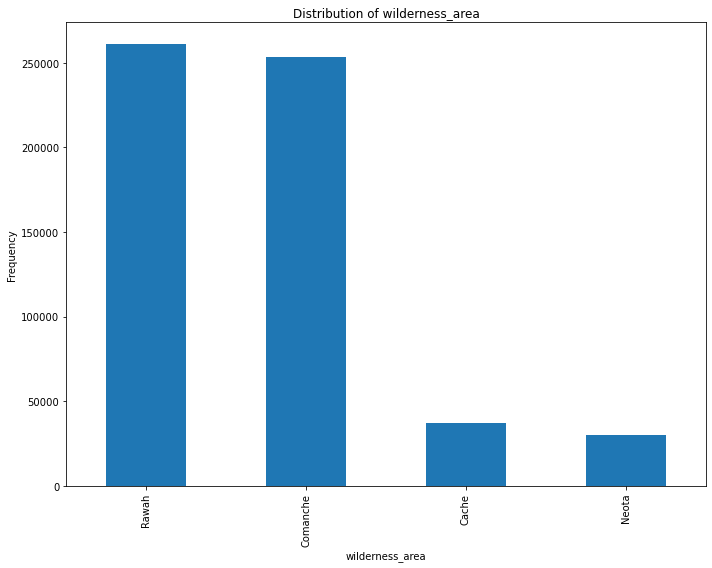

```python
explore_categorical_column(df, "wilderness_area")
```

### 2.2 Exploring Pairs of Columns

### Pair 1 - Elevation vs. Slope

```python
elevation = df['Elevation']
slope = df['Slope']

# Calculate descriptive statistics
correlation = elevation.corr(slope)
covariance = elevation.cov(slope)
median_elevation = np.median(elevation)
median_slope = np.median(slope)

# Print the descriptive statistics
print("Descriptive Statistics:")
print("Correlation between Elevation and Slope:", correlation)
print("Covariance between Elevation and Slope:", covariance)
print("Median Elevation:", median_elevation)
print("Median Slope:", median_slope)
```

```
Descriptive Statistics:
Correlation between Elevation and Slope: -0.242696639313851
Covariance between Elevation and Slope: -508.83617083620175
Median Elevation: 2996.0
Median Slope: 13.0
```

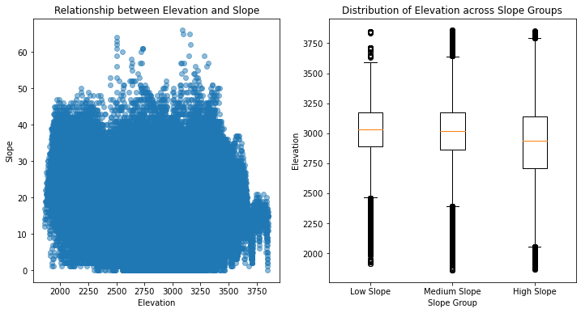

```python
fig, axs = plt.subplots(1, 2, figsize=(12, 6))

# Create a scatter plot
axs[0].scatter(elevation, slope, alpha=0.5)
axs[0].set_xlabel('Elevation')
axs[0].set_ylabel('Slope')
axs[0].set_title('Relationship between Elevation and Slope')

# Define the groups based on Slope categories
slope_groups = ['Low Slope', 'Medium Slope', 'High Slope']
slope_ranges = [(0, 5), (5, 15), (15, df['Slope'].max() + 1)]

# Create a new column in the DataFrame to categorise Slope into groups
df['Slope Group'] = pd.cut(df['Slope'], bins=[range[0] for range in slope_ranges] + [slope_ranges[-1][1]], labels=slope_groups)

# Create the grouped box plot
boxplot_data = [df.loc[df['Slope Group'] == group, 'Elevation'].values for group in slope_groups]
axs[1].boxplot(np.asarray(boxplot_data, dtype=object), labels=slope_groups)

# Add labels and title
axs[1].set_xlabel('Slope Group')
axs[1].set_ylabel('Elevation')
axs[1].set_title('Distribution of Elevation across Slope Groups')

plt.savefig("pair1exploration.png", dpi=300, bbox_inches="tight")
# Show the plot
plt.show()
```

### Pair 2 - Elevation vs Aspect

```python
# Calculate descriptive statistics
elevation_mean = df['Elevation'].mean()
aspect_mean = df['Aspect'].mean()
elevation_std = df['Elevation'].std()
aspect_std = df['Aspect'].std()
correlation = df['Elevation'].corr(df['Aspect'])

# Print the descriptive statistics
print("Descriptive Statistics:")
print(f"Mean Elevation: {elevation_mean}")
print(f"Mean Aspect: {aspect_mean}")
print(f"Standard Deviation (Elevation): {elevation_std}")
print(f"Standard Deviation (Aspect): {aspect_std}")
print(f"Correlation between Elevation and Aspect: {correlation}")
```

```
Descriptive Statistics:
Mean Elevation: 2959.365300544567
Mean Aspect: 155.65680743254873
Standard Deviation (Elevation): 279.9847342506334
Standard Deviation (Aspect): 111.91372100329212
Correlation between Elevation and Aspect: 0.015734938290299576
```

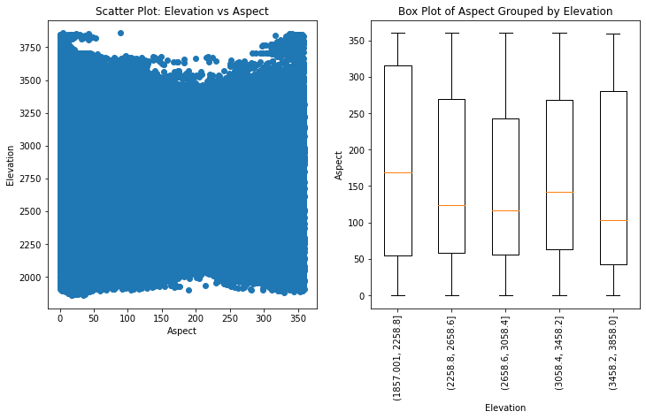

```python
fig, axs = plt.subplots(1, 2, figsize=(12, 6))
# Create a scatter plot
axs[0].scatter(df['Aspect'], df['Elevation'])
axs[0].set_xlabel('Aspect')
axs[0].set_ylabel('Elevation')
axs[0].set_title('Scatter Plot: Elevation vs Aspect')

elevation_groups = df.groupby(pd.cut(df['Elevation'], bins=5))

# Creating a list to store the Aspect values for each group
aspect_groups = [group['Aspect'] for _, group in elevation_groups]

# Convert aspect_groups to a 2D array
aspect_groups_array = np.array(aspect_groups, dtype=object)

# Creating the box plot
axs[1].boxplot(aspect_groups_array, labels=elevation_groups.indices.keys())
axs[1].set_xlabel('Elevation')
axs[1].set_ylabel('Aspect')
axs[1].set_title('Box Plot of Aspect Grouped by Elevation')
plt.setp(axs[1].xaxis.get_majorticklabels(), rotation=90)
plt.savefig("pair2exploration.png", dpi=300, bbox_inches="tight")
plt.show()
```

### Pair 3 - Horizontal_Distance_To_Roadways vs. wilderness_area

```python
# Calculate Descriptive statistics
statistics = df.groupby('wilderness_area')['Horizontal_Distance_To_Roadways'].describe()

# Print the Descriptive statistics
statistics
```

| wilderness_area | count | mean | std | min | 25% | 50% | 75% | max |
| --- | --- | --- | --- | --- | --- | --- | --- | --- |
| Cache | 36968.0 | 733.017123 | 404.869554 | 0.0 | 400.0 | 696.0 | 1050.0 | 1776.0 |
| Comanche | 253364.0 | 1937.118438 | 994.475116 | 0.0 | 1180.0 | 1831.0 | 2610.0 | 5463.0 |
| Neota | 29884.0 | 1008.166477 | 560.678672 | 30.0 | 573.0 | 914.0 | 1401.5 | 2632.0 |
| Rawah | 260796.0 | 3134.408055 | 1743.157038 | 0.0 | 1572.0 | 3155.0 | 4589.0 | 7117.0 |

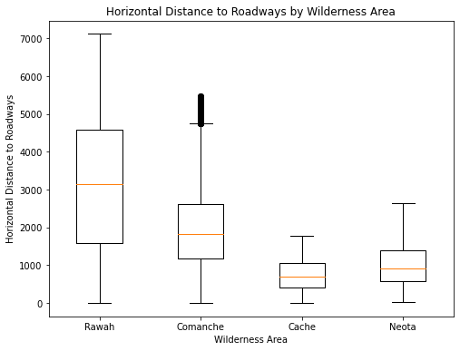

```python
# Create a grouped box plot
grouped_data = df.groupby('wilderness_area')['Horizontal_Distance_To_Roadways']

# Create a list of data values for each wilderness area
data = [grouped_data.get_group(area) for area in df['wilderness_area'].unique()]

fig, ax = plt.subplots(figsize=(8, 6))

# Create the box plot
ax.boxplot(np.asarray(data, dtype=object), labels=df['wilderness_area'].unique())
ax.set_xlabel('Wilderness Area')
ax.set_ylabel('Horizontal Distance to Roadways')
ax.set_title('Horizontal Distance to Roadways by Wilderness Area')
plt.suptitle('')
plt.savefig("pair3exploration.png", dpi=300, bbox_inches="tight")
plt.show()
```

## Pair 4 - Aspect vs. soil_type

```python
# Define the aspect ranges and corresponding labels
aspect_ranges = [(0, 90), (90, 180), (180, 270), (270, 360)]
aspect_labels = ['0-90', '90-180', '180-270', '270-360']

# Create a new column in the DataFrame for aspect groups
df['Aspect_Group'] = pd.cut(df['Aspect'], bins=[0, 90, 180, 270, 360], labels=aspect_labels, include_lowest=True)

# Create a DataFrame with Aspect_Group and Soil_Type columns
df_aspect_soil = df[['Aspect_Group', 'soil_type']]

# Group by Aspect_Group and count the frequency of each Soil_Type
grouped = df_aspect_soil.groupby('Aspect_Group')['soil_type'].value_counts().unstack()

# Print the frequency table
grouped
```

| soil_type Aspect_Group | Bross | Bullwark | Catamount | CatamountFamily | CathedralFamily | Como | Cryaquolis | Cryorthents | Cryumbrepts | Gateview | ... | Rock | RogertFamily | Supervisor | TroutvilleFamily | TypicCryaquepts | TypicCryaquolis | TypicCryaquolls | Unknown | Vanet | VanetFamily |
| --- | --- | --- | --- | --- | --- | --- | --- | --- | --- | --- | --- | --- | --- | --- | --- | --- | --- | --- | --- | --- | --- |
| 0-90 | NaN | 21591.0 | 15466.0 | 1963.0 | 1022.0 | 61194.0 | 1057.0 | 207.0 | 896.0 | 1189.0 | ... | 266.0 | 998.0 | 83.0 | 667.0 | 4886.0 | 1686.0 | 49.0 | 3.0 | 4468.0 | 630.0 |
| 90-180 | 88.0 | 5568.0 | 11323.0 | 5361.0 | 962.0 | 41813.0 | 513.0 | 559.0 | 698.0 | 977.0 | ... | 31.0 | 761.0 | 43.0 | 332.0 | 1875.0 | 975.0 | 32.0 | NaN | 4436.0 | 219.0 |
| 180-270 | 31.0 | 1957.0 | 12026.0 | 7787.0 | 789.0 | 14965.0 | 457.0 | 696.0 | 171.0 | 569.0 | ... | NaN | 50.0 | 29.0 | 55.0 | 684.0 | 437.0 | 383.0 | NaN | 2361.0 | 180.0 |
| 270-360 | NaN | 15928.0 | 13704.0 | 2320.0 | 258.0 | 27445.0 | 818.0 | 149.0 | 126.0 | 687.0 | ... | 1.0 | 90.0 | 24.0 | 93.0 | 1814.0 | 923.0 | 374.0 | NaN | 2835.0 | 568.0 |

4 rows × 29 columns

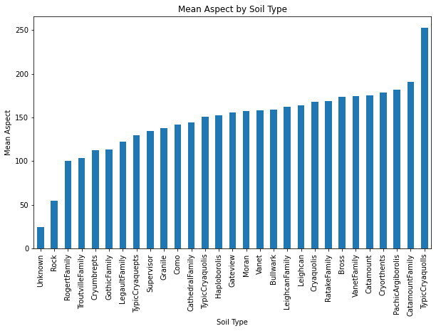

```python
# Calculate the mean Aspect for each soil type
aspect_by_soiltype = df.groupby('soil_type')['Aspect'].mean().sort_values()

# Plotting the mean Aspect by soil type
plt.figure(figsize=(10, 6))
aspect_by_soiltype.plot(kind='bar')
plt.xlabel('Soil Type')
plt.ylabel('Mean Aspect')
plt.title('Mean Aspect by Soil Type')
plt.xticks(rotation=90)
plt.savefig("pair4exploration.png", dpi=300, bbox_inches="tight")
plt.show()
```

### Pair 5 - Aspect vs. Hillshade_Noon

```python
# Calculate descriptive statistics
mean_aspect = df['Aspect'].mean()
mean_hillshade_noon = df['Hillshade_Noon'].mean()
correlation = df['Aspect'].corr(df['Hillshade_Noon'])

# Print descriptive statistics
print("Descriptive Statistics: ")
print("Mean Aspect:", mean_aspect)
print("Mean Hillshade at Noon:", mean_hillshade_noon)
print("Correlation between Aspect and Hillshade at Noon:", correlation)
```

```
Descriptive Statistics:
Mean Aspect: 155.65680743254873
Mean Hillshade at Noon: 223.31871630878535
Correlation between Aspect and Hillshade at Noon: 0.33610296426695485
```

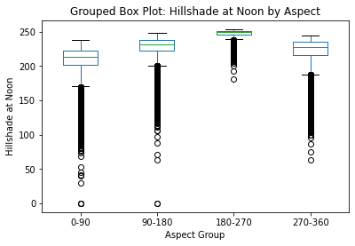

```python
# Define the groups based on Aspect ranges
group_labels = ['0-90', '90-180', '180-270', '270-360']
group_ranges = [(0, 90), (90, 180), (180, 270), (270, 360)]

# Create a new column 'Aspect_Group' in the dataframe based on the ranges
df['Aspect_Group'] = pd.cut(df['Aspect'], bins=[0, 90, 180, 270, 360], labels=group_labels, right=False)

# Create a grouped box plot
plt.figure(figsize=(10, 6))
df.boxplot(column='Hillshade_Noon', by='Aspect_Group', grid=False)
plt.xlabel('Aspect Group')
plt.ylabel('Hillshade at Noon')
plt.title('Grouped Box Plot: Hillshade at Noon by Aspect')
plt.suptitle('')
plt.savefig("pair5exploration.png", dpi=300, bbox_inches="tight")

plt.show()
```

### 2.3 Investigating the Influence of Slope on Forest Cover Types:

#### What is the Relationship between Slope and Different Forest Cover Types?

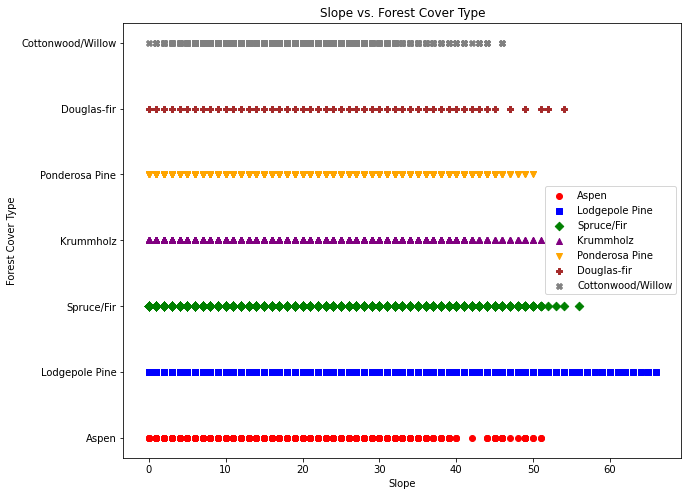

```python
# Select the relevant columns for analysis
slope_cover_columns = ['Slope', 'Cover_Type']

# Subset the data for the selected columns
subset_data = df[slope_cover_columns]

# Map the cover type values to their corresponding labels
cover_type_labels = {
    1: 'Spruce/Fir',
    2: 'Lodgepole Pine',
    3: 'Ponderosa Pine',
    4: 'Cottonwood/Willow',
    5: 'Aspen',
    6: 'Douglas-fir',
    7: 'Krummholz'
}

# Rename the cover type values with their labels
subset_data.loc[:, 'Cover_Type'] = subset_data['Cover_Type'].map(cover_type_labels)

# Create a scatter plot
fig, ax = plt.subplots(figsize=(10, 8))

cover_types = subset_data['Cover_Type'].unique()

# Assign different colors/markers to each cover type
colors = ['red', 'blue', 'green', 'purple', 'orange', 'brown', 'gray']
markers = ['o', 's', 'D', '^', 'v', 'P', 'X']

scatter_data = []

for i, cover_type in enumerate(cover_types):
    cover_type_data = subset_data[subset_data['Cover_Type'] == cover_type]
    ax.scatter(cover_type_data['Slope'], cover_type_data['Cover_Type'], c=colors[i], marker=markers[i], label=cover_type)

    # Store scatter plot data into a list
    scatter_data.extend(list(zip(cover_type_data['Slope'], cover_type_data['Cover_Type'])))

# Set plot title and labels
ax.set_title('Slope vs. Forest Cover Type')
ax.set_xlabel('Slope')
ax.set_ylabel('Forest Cover Type')
ax.legend()
plt.savefig("slope_vs_covertype.png", dpi=300, bbox_inches="tight")
plt.show()
```

```python
# Create a DataFrame from the scatter plot data
scatter_df = pd.DataFrame(scatter_data, columns=['Slope', 'Cover_Type'])

# Summary statistics for each cover type and slope combination
summary_df = scatter_df.groupby(['Cover_Type']).agg({'Slope': ['min', 'max', 'mean', 'median']})


summary_df
```

| Cover_Type | Slope min | Slope max | Slope mean | Slope median |
| --- | --- | --- | --- | --- |
| Aspen | 0 | 51 | 16.641315 | 16 |
| Cottonwood/Willow | 0 | 46 | 18.528941 | 19 |
| Douglas-fir | 0 | 54 | 19.048886 | 19 |
| Krummholz | 0 | 51 | 14.255924 | 13 |
| Lodgepole Pine | 0 | 66 | 13.550499 | 13 |
| Ponderosa Pine | 0 | 50 | 20.770208 | 21 |
| Spruce/Fir | 0 | 56 | 13.127110 | 12 |

## Task 3 - Data Modelling

### 3.1 Data Splitting

### Sampling a 1% Subset of the Dataset using Stratified Sampling

```python
from sklearn.model_selection import train_test_split

# Extract the features and target variable
X = df_main.drop('Cover_Type', axis=1)
y = df_main['Cover_Type']

mapping = {
    1: 'Spruce/Fir',
    2: 'Lodgepole Pine',
    3: 'Ponderosa Pine',
    4: 'Cottonwood/Willow',
    5: 'Aspen',
    6: 'Douglas-fir',
    7: 'Krummholz'
}

# Map the 'y' values based on the mapping dictionary
y = y.map(mapping)


# Perform stratified sampling on the entire dataset to obtain a 1% sample
_ , X_sample, _, y_sample = train_test_split(X, y, test_size=0.01, stratify=y, random_state = 1)

X_sample
```

|  | Elevation | Aspect | Slope | Horizontal_Distance_To_Hydrology | Vertical_Distance_To_Hydrology | Horizontal_Distance_To_Roadways | Hillshade_9am | Hillshade_Noon | Hillshade_3pm | Horizontal_Distance_To_Fire_Points | ... | Leighcan_Catamount_complex | Catamount_Rock_outcrop_Leighcan_complex | Leighcan_Catamount_Rock_outcrop_complex | Cryorthents_Rock_land_complex | Cryumbrepts_Rock_outcrop_Cryaquepts_complex | Bross_Rock_land_Cryumbrepts_complex | Rock_outcrop_Cryumbrepts_Cryorthents_complex | Leighcan_Moran_Cryaquolls_complex | Moran_Cryorthents_Leighcan_complex | Moran_Cryorthents_Rock_land_complex |
| --- | --- | --- | --- | --- | --- | --- | --- | --- | --- | --- | --- | --- | --- | --- | --- | --- | --- | --- | --- | --- | --- |
| 534599 | 3085 | 22 | 15 | 153 | 28 | 3713 | 209 | 206 | 130 | 2012 | ... | 0 | 0 | 0 | 0 | 0 | 0 | 0 | 0 | 0 | 0 |
| 417873 | 2663 | 123 | 15 | 0 | 0 | 1935 | 244 | 228 | 109 | 2412 | ... | 0 | 0 | 0 | 0 | 0 | 0 | 0 | 0 | 0 | 0 |
| 469209 | 3061 | 22 | 7 | 60 | 13 | 973 | 216 | 225 | 146 | 1624 | ... | 0 | 0 | 0 | 0 | 0 | 0 | 0 | 0 | 0 | 0 |
| 464529 | 3345 | 190 | 11 | 391 | 66 | 3531 | 220 | 249 | 161 | 1507 | ... | 0 | 1 | 0 | 0 | 0 | 0 | 0 | 0 | 0 | 0 |
| 392572 | 3270 | 128 | 16 | 794 | 154 | 2460 | 245 | 228 | 108 | 2445 | ... | 0 | 0 | 1 | 0 | 0 | 0 | 0 | 0 | 0 | 0 |
| ... | ... | ... | ... | ... | ... | ... | ... | ... | ... | ... | ... | ... | ... | ... | ... | ... | ... | ... | ... | ... | ... |
| 443210 | 2987 | 345 | 14 | 450 | 66 | 1598 | 191 | 217 | 164 | 484 | ... | 1 | 0 | 0 | 0 | 0 | 0 | 0 | 0 | 0 | 0 |
| 140378 | 3086 | 11 | 15 | 558 | 22 | 3542 | 202 | 208 | 140 | 2874 | ... | 0 | 0 | 0 | 0 | 0 | 0 | 0 | 0 | 0 | 0 |
| 205045 | 3198 | 51 | 6 | 0 | 0 | 5550 | 223 | 227 | 139 | 912 | ... | 0 | 0 | 0 | 0 | 0 | 0 | 0 | 0 | 0 | 0 |
| 158043 | 3089 | 180 | 9 | 319 | 62 | 4902 | 224 | 246 | 155 | 1762 | ... | 0 | 0 | 0 | 0 | 0 | 0 | 0 | 0 | 0 | 0 |
| 454591 | 3046 | 57 | 10 | 85 | 8 | 1242 | 227 | 219 | 125 | 3007 | ... | 0 | 0 | 0 | 0 | 0 | 0 | 0 | 0 | 0 | 0 |

5811 rows × 54 columns

### Splitting the data into a training set and a test set to form three different suites of training and test sets

```python
# Split the 1% sample into three suites
# Suite1: 50% for training and 50% for testing
X_suite1_train, X_suite1_test, y_suite1_train, y_suite1_test = train_test_split(X_sample, y_sample, test_size=0.5,
                                                                                stratify=y_sample, random_state = 1)

# Suite2: 60% for training and 40% for testing
X_suite2_train, X_suite2_test, y_suite2_train, y_suite2_test = train_test_split(X_sample, y_sample, test_size=0.4,
                                                                                stratify=y_sample, random_state = 1)

# Suite3: 80% for training and 20% for testing
X_suite3_train, X_suite3_test, y_suite3_train, y_suite3_test = train_test_split(X_sample, y_sample, test_size=0.2,
                                                                                stratify=y_sample, random_state = 1)
```

### Standardisation

```python
from sklearn.preprocessing import StandardScaler
# Create an instance of the StandardScaler
scaler = StandardScaler()

# Fit the scaler on the Suite 1 training data and transform the data
X_suite1_train = scaler.fit_transform(X_suite1_train)
X_suite1_test = scaler.transform(X_suite1_test)

# Fit the scaler on the Suite 2 training data and transform the data
X_suite2_train = scaler.fit_transform(X_suite2_train)
X_suite2_test = scaler.transform(X_suite2_test)

# Fit the scaler on the Suite 3 training data and transform the data
X_suite3_train = scaler.fit_transform(X_suite3_train)
X_suite3_test = scaler.transform(X_suite3_test)
```

### 3.2 Training models

### Function for training and evaluating a machine learning model (KNN or Decision Tree), returning the model, confusion matrices, and evaluation metrics.

```python
from sklearn.model_selection import cross_val_score
from sklearn.metrics import confusion_matrix, accuracy_score, precision_score, recall_score, f1_score
from sklearn.neighbors import KNeighborsClassifier
from sklearn.tree import DecisionTreeClassifier

def train_and_evaluate_model(X_train, y_train, X_test, y_test, model_type,cv=5):
    if model_type == "KNN":

        # Set the range of K values to try
        k_values = [3, 5, 7, 10]

        # Perform cross-validation and store the mean accuracy scores
        cv_scores = []
        for k in k_values:
            # Create the KNN classifier
            knn = KNeighborsClassifier(n_neighbors=k)

            # Perform cross-validation and compute the mean score
            scores = cross_val_score(knn, X_train, y_train, cv=5)

            # Append the mean score to the cv_scores list
            cv_scores.append(scores.mean())

        # Find the best K value
        best_k = k_values[np.argmax(cv_scores)]
        print("Best K:", best_k)
        print("Cross-validation score:",max(cv_scores))

        # Train the model using the best K value
        model = KNeighborsClassifier(n_neighbors=best_k)

    elif model_type == "DecisionTree":
        max_depth_values = [3, 5, 7, 10]

        cv_scores = []

        # Iterate over each max_depth value
        for max_depth in max_depth_values:
            # Create the Decision Tree Classifier
            dtc = DecisionTreeClassifier(max_depth=max_depth, random_state=42)

            # Perform cross-validation and compute the mean score
            scores = cross_val_score(dtc, X_train, y_train, cv=5)
            mean_score = scores.mean()

            # Append the mean score to the cv_scores list
            cv_scores.append(mean_score)

        # Find the best max_depth value
        best_max_depth = max_depth_values[np.argmax(cv_scores)]
        print("Best max_depth:", best_max_depth)
        print("Cross-validation score:",max(cv_scores))

        # Train the model using the best max_depth value
        model = DecisionTreeClassifier(max_depth=best_max_depth)


    else:
        raise ValueError("Invalid model_type. Supported values are 'KNN' and 'DecisionTree'.")

    # Train the model
    model.fit(X_train, y_train)

    # Predict on training and test sets
    y_train_pred = model.predict(X_train)
    y_test_pred = model.predict(X_test)

    #Create confusion matric for both training and test set
    train_confusion_matrix = confusion_matrix(y_train, y_train_pred)
    test_confusion_matrix = confusion_matrix(y_test, y_test_pred)

    # Evaluate performance metrics
    train_accuracy = accuracy_score(y_train, y_train_pred)
    test_accuracy = accuracy_score(y_test, y_test_pred)
    train_precision = precision_score(y_train, y_train_pred, average='weighted', zero_division=0, labels=np.unique(y_train_pred))
    test_precision = precision_score(y_test, y_test_pred, average='weighted', zero_division=0, labels=np.unique(y_test_pred))
    train_recall = recall_score(y_train, y_train_pred, average='weighted', zero_division=0, labels=np.unique(y_train_pred))
    test_recall = recall_score(y_test, y_test_pred, average='weighted', zero_division=0, labels=np.unique(y_test_pred))
    train_f1 = f1_score(y_train, y_train_pred, average='weighted', zero_division=0, labels=np.unique(y_train_pred))
    test_f1 = f1_score(y_test, y_test_pred, average='weighted', zero_division=0, labels=np.unique(y_test_pred))

    # Store the evaluation metrics in a dictionary

    evaluation_metrics = {
        'Train Accuracy': train_accuracy,
        'Test Accuracy': test_accuracy,
        'Train Precision': train_precision,
        'Test Precision': test_precision,
        'Train Recall': train_recall,
        'Test Recall': test_recall,
        'Train F1 Score': train_f1,
        'Test F1 Score': test_f1
    }

    return model, train_confusion_matrix, test_confusion_matrix, evaluation_metrics
```

### Function to print confusion matrix

```python
def print_confusion_matrix(model, suite, train_cm, test_cm, labels):
    # Create subplots for KNN and DT confusion matrices
    fig, axs = plt.subplots(1, 2, figsize=(10, 5))

    # Plot Training set confusion matrix heatmap
    axs[0].imshow(train_cm, cmap='Blues')
    axs[0].set_xticks(np.arange(len(labels)))
    axs[0].set_yticks(np.arange(len(labels)))
    axs[0].set_xticklabels(labels, rotation=90)
    axs[0].set_yticklabels(labels)
    axs[0].set_title(model + ' Confusion Matrix for Training Set')
    axs[0].set_xlabel('Predicted label')
    axs[0].set_ylabel('True label')

    # Plot Test Set confusion matrix heatmap
    axs[1].imshow(test_cm, cmap='Blues')
    axs[1].set_xticks(np.arange(len(labels)))
    axs[1].set_yticks(np.arange(len(labels)))
    axs[1].set_xticklabels(labels, rotation=90)
    axs[1].set_yticklabels(labels)
    axs[1].set_title(model + ' Confusion Matrix for Test Set')
    axs[1].set_xlabel('Predicted label')
    axs[1].set_ylabel('True label')

    # Loop over data dimensions and create text annotations
    for i in range(len(labels)):
        for j in range(len(labels)):
            axs[0].text(j, i, train_cm[i, j], ha="center", va="center", color="black")
            axs[1].text(j, i, test_cm[i, j], ha="center", va="center", color="black")

    plt.tight_layout()
    plt.savefig(model + "_" + suite + "_confusion_matrix.png", dpi=300, bbox_inches="tight")

    plt.show()
```

### A DataFrame to serve as a summary table for storing performance metrics of different suites and models

```python
metrics_df = pd.DataFrame(columns=['Suite',
                                   'KNN Train Accuracy',
                                   'KNN Test Accuracy',
                                   'KNN Train Precision',
                                   'KNN Test Precision',
                                   'KNN Train Recall',
                                   'KNN Test Recall',
                                   'KNN Train F1 Score',
                                   'KNN Test F1 Score',
                                   'DT Train Accuracy',
                                   'DT Test Accuracy',
                                   'DT Train Precision',
                                   'DT Test Precision',
                                   'DT Train Recall',
                                   'DT Test Recall',
                                   'DT Train F1 Score',
                                   'DT Test F1 Score'])

metrics_df
```

|  | Suite | KNN Train Accuracy | KNN Test Accuracy | KNN Train Precision | KNN Test Precision | KNN Train Recall | KNN Test Recall | KNN Train F1 Score | KNN Test F1 Score | DT Train Accuracy | DT Test Accuracy | DT Train Precision | DT Test Precision | DT Train Recall | DT Test Recall | DT Train F1 Score | DT Test F1 Score |
| --- | --- | --- | --- | --- | --- | --- | --- | --- | --- | --- | --- | --- | --- | --- | --- | --- | --- |

### Suite 1

```python
# Train and evaluate KNN model
knn_model, knn_train_cm, knn_test_cm, knn_metrics = train_and_evaluate_model(X_suite1_train, y_suite1_train,
                                                                             X_suite1_test, y_suite1_test, "KNN")

# Train and evaluate Decision Tree model
dt_model, dt_train_cm, dt_test_cm, dt_metrics = train_and_evaluate_model(X_suite1_train, y_suite1_train,
                                                                         X_suite1_test, y_suite1_test, "DecisionTree")
```

```
Best K: 3
Cross-validation score: 0.6812392426850258
Best max_depth: 5
Cross-validation score: 0.6953528399311532
```

```
KNN Model - Suite 1
```

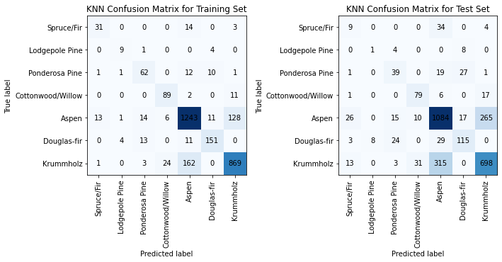

```
Decision Tree Model - Suite 1
```

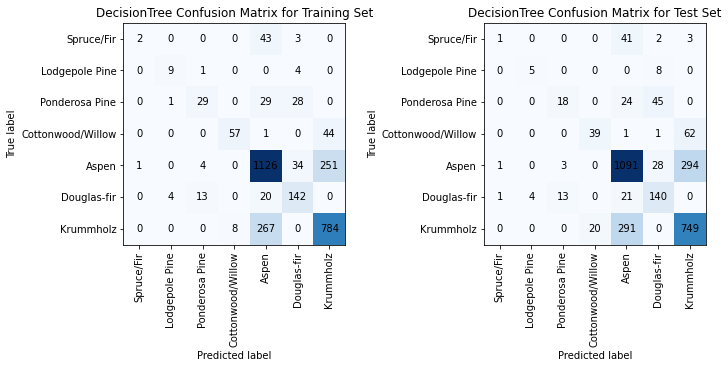

```python
labels = list(mapping.values())

# Print Confusion Matrix and Evaluation Metrics for KNN model
print("KNN Model - Suite 1")
print("*"*100)
print_confusion_matrix("KNN", "Suite 1", knn_train_cm, knn_test_cm, labels)
print()

# Print Confusion Matrix and Evaluation Metrics for Decision Tree model
print("Decision Tree Model - Suite 1")
print("*"*100)
print_confusion_matrix("DecisionTree", "Suite 1", dt_train_cm, dt_test_cm, labels)
```

```python
# Append a row for Suite 1 in the metrics_df DataFrame
suite1_metrics = {'Suite': 'Suite 1',
                  'KNN Train Accuracy': knn_metrics['Train Accuracy'],
                  'KNN Test Accuracy': knn_metrics['Test Accuracy'],
                  'KNN Train Precision': knn_metrics['Train Precision'],
                  'KNN Test Precision': knn_metrics['Test Precision'],
                  'KNN Train Recall': knn_metrics['Train Recall'],
                  'KNN Test Recall': knn_metrics['Test Recall'],
                  'KNN Train F1 Score': knn_metrics['Train F1 Score'],
                  'KNN Test F1 Score': knn_metrics['Test F1 Score'],
                  'DT Train Accuracy': dt_metrics['Train Accuracy'],
                  'DT Test Accuracy': dt_metrics['Test Accuracy'],
                  'DT Train Precision': dt_metrics['Train Precision'],
                  'DT Test Precision': dt_metrics['Test Precision'],
                  'DT Train Recall': dt_metrics['Train Recall'],
                  'DT Test Recall': dt_metrics['Test Recall'],
                  'DT Train F1 Score': dt_metrics['Train F1 Score'],
                  'DT Test F1 Score': dt_metrics['Test F1 Score']}

metrics_df = metrics_df.append(suite1_metrics, ignore_index=True)

metrics_df
```

|  | Suite | KNN Train Accuracy | KNN Test Accuracy | KNN Train Precision | KNN Test Precision | KNN Train Recall | KNN Test Recall | KNN Train F1 Score | KNN Test F1 Score | DT Train Accuracy | DT Test Accuracy | DT Train Precision | DT Test Precision | DT Train Recall | DT Test Recall | DT Train F1 Score | DT Test F1 Score |
| --- | --- | --- | --- | --- | --- | --- | --- | --- | --- | --- | --- | --- | --- | --- | --- | --- | --- |
| 0 | Suite 1 | 0.84475 | 0.696834 | 0.845736 | 0.696674 | 0.84475 | 0.696834 | 0.844842 | 0.695984 | 0.739759 | 0.703028 | 0.739077 | 0.69437 | 0.739759 | 0.703028 | 0.731809 | 0.692152 |

### Suite 2

```python
# Train and evaluate KNN model
knn_model, knn_train_cm, knn_test_cm, knn_metrics = train_and_evaluate_model(X_suite2_train, y_suite2_train,
                                                                             X_suite2_test, y_suite2_test, "KNN")

# Train and evaluate Decision Tree model
dt_model, dt_train_cm, dt_test_cm, dt_metrics = train_and_evaluate_model(X_suite2_train, y_suite2_train,
                                                                         X_suite2_test, y_suite2_test, "DecisionTree")
```

```
Best K: 3
Cross-validation score: 0.6876059082519024
Best max_depth: 5
Cross-validation score: 0.7002298018935018
```

```
KNN Model - Suite 2
```

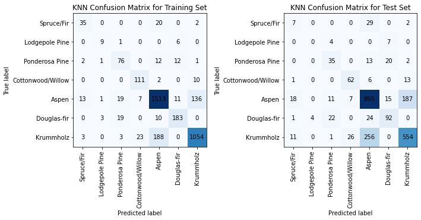

```
Decision Tree Model - Suite 2
```

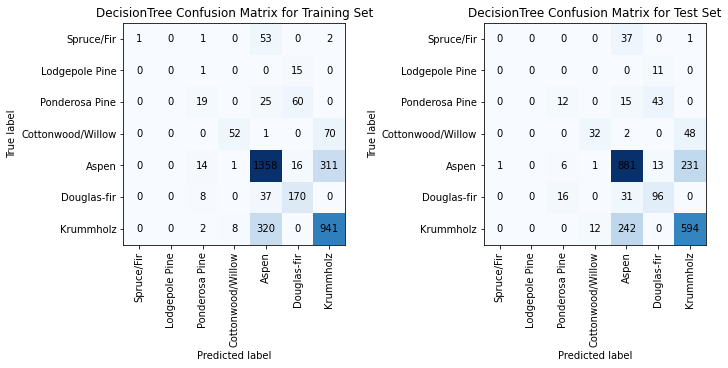

```python
# Print Confusion Matrix and Evaluation Metrics for KNN model
print("KNN Model - Suite 2")
print("*"*100)
print_confusion_matrix("KNN", "Suite 2", knn_train_cm, knn_test_cm, labels)
print()

# Print Confusion Matrix and Evaluation Metrics for Decision Tree model
print("Decision Tree Model - Suite 2")
print("*"*100)
print_confusion_matrix("DecisionTree", "Suite 2", dt_train_cm, dt_test_cm, labels)
```

```python
# Append a row for Suite 2 in the metrics_df DataFrame
suite2_metrics = {'Suite': 'Suite 2',
                  'KNN Train Accuracy': knn_metrics['Train Accuracy'],
                  'KNN Test Accuracy': knn_metrics['Test Accuracy'],
                  'KNN Train Precision': knn_metrics['Train Precision'],
                  'KNN Test Precision': knn_metrics['Test Precision'],
                  'KNN Train Recall': knn_metrics['Train Recall'],
                  'KNN Test Recall': knn_metrics['Test Recall'],
                  'KNN Train F1 Score': knn_metrics['Train F1 Score'],
                  'KNN Test F1 Score': knn_metrics['Test F1 Score'],
                  'DT Train Accuracy': dt_metrics['Train Accuracy'],
                  'DT Test Accuracy': dt_metrics['Test Accuracy'],
                  'DT Train Precision': dt_metrics['Train Precision'],
                  'DT Test Precision': dt_metrics['Test Precision'],
                  'DT Train Recall': dt_metrics['Train Recall'],
                  'DT Test Recall': dt_metrics['Test Recall'],
                  'DT Train F1 Score': dt_metrics['Train F1 Score'],
                  'DT Test F1 Score': dt_metrics['Test F1 Score']}

metrics_df = metrics_df.append(suite2_metrics, ignore_index=True)

metrics_df
```

|  | Suite | KNN Train Accuracy | KNN Test Accuracy | KNN Train Precision | KNN Test Precision | KNN Train Recall | KNN Test Recall | KNN Train F1 Score | KNN Test F1 Score | DT Train Accuracy | DT Test Accuracy | DT Train Precision | DT Test Precision | DT Train Recall | DT Test Recall | DT Train F1 Score | DT Test F1 Score |
| --- | --- | --- | --- | --- | --- | --- | --- | --- | --- | --- | --- | --- | --- | --- | --- | --- | --- |
| 0 | Suite 1 | 0.844750 | 0.696834 | 0.845736 | 0.696674 | 0.844750 | 0.696834 | 0.844842 | 0.695984 | 0.739759 | 0.703028 | 0.739077 | 0.694370 | 0.739759 | 0.703028 | 0.731809 | 0.692152 |
| 1 | Suite 2 | 0.855135 | 0.707527 | 0.856251 | 0.705881 | 0.855135 | 0.707527 | 0.855136 | 0.705186 | 0.728916 | 0.694624 | 0.730830 | 0.678422 | 0.732277 | 0.697926 | 0.718971 | 0.684965 |

### Suite 3

```python
# Train and evaluate KNN model
knn_model, knn_train_cm, knn_test_cm, knn_metrics = train_and_evaluate_model(X_suite3_train, y_suite3_train,
                                                                             X_suite3_test, y_suite3_test, "KNN")

# Train and evaluate Decision Tree model
dt_model, dt_train_cm, dt_test_cm, dt_metrics = train_and_evaluate_model(X_suite3_train, y_suite3_train,
                                                                         X_suite3_test, y_suite3_test, "DecisionTree")
```

```
Best K: 3
Cross-validation score: 0.6985737930715187
Best max_depth: 7
Cross-validation score: 0.7117050360544925
```

```
KNN Model - Suite 3
```

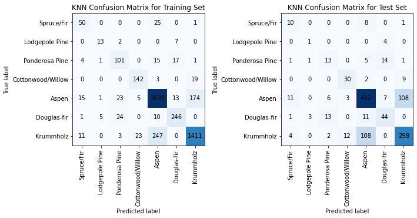

```
Decision Tree Model - Suite 3
```

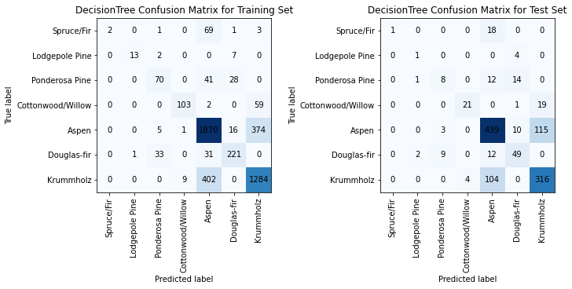

```python
# Print Confusion Matrix and Evaluation Metrics for KNN model
print("KNN Model - Suite 3")
print("*"*100)
print_confusion_matrix("KNN", "Suite 3", knn_train_cm, knn_test_cm, labels)
print()

# Print Confusion Matrix and Evaluation Metrics for Decision Tree model
print("Decision Tree Model - Suite 3")
print("*"*100)
print_confusion_matrix("DecisionTree", "Suite 3", dt_train_cm, dt_test_cm, labels)
```

```python
# Append a row for Suite 3 in the metrics_df DataFrame
suite3_metrics = {'Suite': 'Suite 3',
                  'KNN Train Accuracy': knn_metrics['Train Accuracy'],
                  'KNN Test Accuracy': knn_metrics['Test Accuracy'],
                  'KNN Train Precision': knn_metrics['Train Precision'],
                  'KNN Test Precision': knn_metrics['Test Precision'],
                  'KNN Train Recall': knn_metrics['Train Recall'],
                  'KNN Test Recall': knn_metrics['Test Recall'],
                  'KNN Train F1 Score': knn_metrics['Train F1 Score'],
                  'KNN Test F1 Score': knn_metrics['Test F1 Score'],
                  'DT Train Accuracy': dt_metrics['Train Accuracy'],
                  'DT Test Accuracy': dt_metrics['Test Accuracy'],
                  'DT Train Precision': dt_metrics['Train Precision'],
                  'DT Test Precision': dt_metrics['Test Precision'],
                  'DT Train Recall': dt_metrics['Train Recall'],
                  'DT Test Recall': dt_metrics['Test Recall'],
                  'DT Train F1 Score': dt_metrics['Train F1 Score'],
                  'DT Test F1 Score': dt_metrics['Test F1 Score']}

metrics_df = metrics_df.append(suite3_metrics, ignore_index=True)
```

### 3.3 Comparing the models

### Summary table comparing performance metrics such as accuracy, precision, recall, and F1 score for both the training and test sets of KNN (K-Nearest Neighbors) and DT (Decision Tree) models across different suites

```python
metrics_df
```

|  | Suite | KNN Train Accuracy | KNN Test Accuracy | KNN Train Precision | KNN Test Precision | KNN Train Recall | KNN Test Recall | KNN Train F1 Score | KNN Test F1 Score | DT Train Accuracy | DT Test Accuracy | DT Train Precision | DT Test Precision | DT Train Recall | DT Test Recall | DT Train F1 Score | DT Test F1 Score |
| --- | --- | --- | --- | --- | --- | --- | --- | --- | --- | --- | --- | --- | --- | --- | --- | --- | --- |
| 0 | Suite 1 | 0.844750 | 0.696834 | 0.845736 | 0.696674 | 0.844750 | 0.696834 | 0.844842 | 0.695984 | 0.739759 | 0.703028 | 0.739077 | 0.694370 | 0.739759 | 0.703028 | 0.731809 | 0.692152 |
| 1 | Suite 2 | 0.855135 | 0.707527 | 0.856251 | 0.705881 | 0.855135 | 0.707527 | 0.855136 | 0.705186 | 0.728916 | 0.694624 | 0.730830 | 0.678422 | 0.732277 | 0.697926 | 0.718971 | 0.684965 |
| 2 | Suite 3 | 0.860155 | 0.711952 | 0.861150 | 0.714042 | 0.860155 | 0.711952 | 0.860253 | 0.712684 | 0.766566 | 0.717971 | 0.771312 | 0.719824 | 0.766566 | 0.717971 | 0.759640 | 0.709427 |

### Bar plots comparing the performance of two models. Each bar plot represents the accuracy scores of the models on both the training and test sets across different suites

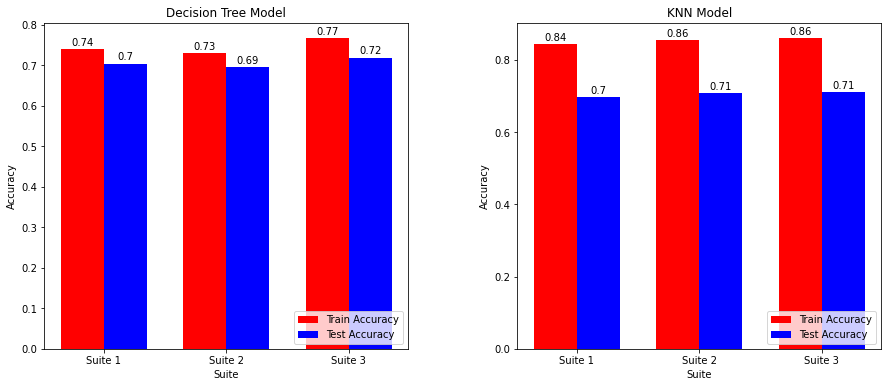

```python
# Set the width of each bar
bar_width = 0.35

# Define the index for the x-axis
index = np.arange(len(metrics_df['Suite']))

# Create a figure with two subplots
fig, axes = plt.subplots(1, 2, figsize=(15, 6))

# Plot for Decision Tree model
axes[0].bar(index - bar_width/2, metrics_df['DT Train Accuracy'], width=bar_width, color='red', label='Train Accuracy')
axes[0].bar(index + bar_width/2, metrics_df['DT Test Accuracy'], width=bar_width, color='blue', label='Test Accuracy')
axes[0].set_xlabel('Suite')
axes[0].set_ylabel('Accuracy')
axes[0].set_title('Decision Tree Model')
axes[0].set_xticks(index)
axes[0].set_xticklabels(metrics_df['Suite'])
axes[0].legend(loc='lower right')

# Add labels to the bars in the Decision Tree plot
for i, v in enumerate(metrics_df['DT Train Accuracy']):
    axes[0].text(i - bar_width/2, v + 0.01, str(round(v, 2)), ha='center', color='black')
for i, v in enumerate(metrics_df['DT Test Accuracy']):
    axes[0].text(i + bar_width/2, v + 0.01, str(round(v, 2)), ha='center', color='black')

# Plot for KNN model
axes[1].bar(index - bar_width/2, metrics_df['KNN Train Accuracy'], width=bar_width, color='red', label='Train Accuracy')
axes[1].bar(index + bar_width/2, metrics_df['KNN Test Accuracy'], width=bar_width, color='blue', label='Test Accuracy')
axes[1].set_xlabel('Suite')
axes[1].set_ylabel('Accuracy')
axes[1].set_title('KNN Model')
axes[1].set_xticks(index)
axes[1].set_xticklabels(metrics_df['Suite'])
axes[1].legend(loc='lower right')

# Add labels to the bars in the KNN plot
for i, v in enumerate(metrics_df['KNN Train Accuracy']):
    axes[1].text(i - bar_width/2, v + 0.01, str(round(v, 2)), ha='center', color='black')
for i, v in enumerate(metrics_df['KNN Test Accuracy']):
    axes[1].text(i + bar_width/2, v + 0.01, str(round(v, 2)), ha='center', color='black')

# Adjust the spacing between subplots
plt.subplots_adjust(wspace=0.3)

plt.savefig("comparison_bar_plot",  dpi=300, bbox_inches="tight")
plt.show()
```

### Line Plot to compare the train and test precision, recall, and F1 scores of the KNN and DT models

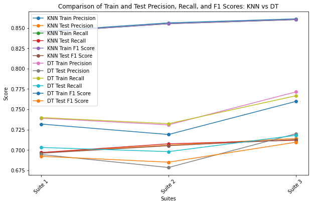

```python
# Extract the required data from the summary table
suites = metrics_df['Suite']
knn_train_precision = metrics_df['KNN Train Precision']
knn_test_precision = metrics_df['KNN Test Precision']
knn_train_recall = metrics_df['KNN Train Recall']
knn_test_recall = metrics_df['KNN Test Recall']
knn_train_f1 = metrics_df['KNN Train F1 Score']
knn_test_f1 = metrics_df['KNN Test F1 Score']
dt_train_precision = metrics_df['DT Train Precision']
dt_test_precision = metrics_df['DT Test Precision']
dt_train_recall = metrics_df['DT Train Recall']
dt_test_recall = metrics_df['DT Test Recall']
dt_train_f1 = metrics_df['DT Train F1 Score']
dt_test_f1 = metrics_df['DT Test F1 Score']

# Set the figure size
plt.figure(figsize=(10, 6))

# Line plot for KNN precision, recall, and F1 score
plt.plot(suites, knn_train_precision, marker='o', label='KNN Train Precision')
plt.plot(suites, knn_test_precision, marker='o', label='KNN Test Precision')
plt.plot(suites, knn_train_recall, marker='o', label='KNN Train Recall')
plt.plot(suites, knn_test_recall, marker='o', label='KNN Test Recall')
plt.plot(suites, knn_train_f1, marker='o', label='KNN Train F1 Score')
plt.plot(suites, knn_test_f1, marker='o', label='KNN Test F1 Score')

# Line plot for DT precision, recall, and F1 score
plt.plot(suites, dt_train_precision, marker='o', label='DT Train Precision')
plt.plot(suites, dt_test_precision, marker='o', label='DT Test Precision')
plt.plot(suites, dt_train_recall, marker='o', label='DT Train Recall')
plt.plot(suites, dt_test_recall, marker='o', label='DT Test Recall')
plt.plot(suites, dt_train_f1, marker='o', label='DT Train F1 Score')
plt.plot(suites, dt_test_f1, marker='o', label='DT Test F1 Score')

# Set the labels, title, and legend
plt.xlabel('Suites')
plt.ylabel('Score')
plt.title('Comparison of Train and Test Precision, Recall, and F1 Scores: KNN vs DT')
plt.legend()
plt.xticks(rotation=45)

plt.savefig("comparison_line_plot",  dpi=300, bbox_inches="tight")
plt.show()
```